# Supervised Learning - Foundations Project: ReCell

## Problem Statement

### Business Context

Buying and selling used phones and tablets used to be something that happened on a handful of online marketplace sites. But the used and refurbished device market has grown considerably over the past decade, and a new IDC (International Data Corporation) forecast predicts that the used phone market would be worth \$52.7bn by 2023 with a compound annual growth rate (CAGR) of 13.6% from 2018 to 2023. This growth can be attributed to an uptick in demand for used phones and tablets that offer considerable savings compared with new models.

Refurbished and used devices continue to provide cost-effective alternatives to both consumers and businesses that are looking to save money when purchasing one. There are plenty of other benefits associated with the used device market. Used and refurbished devices can be sold with warranties and can also be insured with proof of purchase. Third-party vendors/platforms, such as Verizon, Amazon, etc., provide attractive offers to customers for refurbished devices. Maximizing the longevity of devices through second-hand trade also reduces their environmental impact and helps in recycling and reducing waste. The impact of the COVID-19 outbreak may further boost this segment as consumers cut back on discretionary spending and buy phones and tablets only for immediate needs.

### Objective

The rising potential of this comparatively under-the-radar market fuels the need for an ML-based solution to develop a dynamic pricing strategy for used and refurbished devices. ReCell, a startup aiming to tap the potential in this market, has hired you as a data scientist. They want you to analyze the data provided and build a linear regression model to predict the price of a used phone/tablet and identify factors that significantly influence it.

### Data Description

The data contains the different attributes of used/refurbished phones and tablets. The data was collected in the year 2021. The detailed data dictionary is given below.

- brand_name: Name of manufacturing brand
- os: OS on which the device runs
- screen_size: Size of the screen in cm
- 4g: Whether 4G is available or not
- 5g: Whether 5G is available or not
- main_camera_mp: Resolution of the rear camera in megapixels
- selfie_camera_mp: Resolution of the front camera in megapixels
- int_memory: Amount of internal memory (ROM) in GB
- ram: Amount of RAM in GB
- battery: Energy capacity of the device battery in mAh
- weight: Weight of the device in grams
- release_year: Year when the device model was released
- days_used: Number of days the used/refurbished device has been used
- normalized_new_price: Normalized price of a new device of the same model in euros
- normalized_used_price: Normalized price of the used/refurbished device in euros

## Importing necessary libraries

```python
# Libraries to help with reading and manipulating data
import numpy as np
import pandas as pd

#Step 1: Import important packages into python import pandas as pd import numpy as np import seaborn as sns
import matplotlib.pyplot as plt
from scipy.stats import pearsonr
from statsmodels.formula.api import ols
from statsmodels.graphics.gofplots import ProbPlot
import statsmodels.api as sm
from scipy import stats

import seaborn as sns

sns.set()

# split the data into train and test
from sklearn.model_selection import train_test_split

# to build linear regression_model using statsmodels
import statsmodels.api as sm

# to compute VIF
from statsmodels.stats.outliers_influence import variance_inflation_factor

# to check model performance
from sklearn.metrics import mean_absolute_error, mean_squared_error, r2_score
```

## Loading the dataset

```python
from google.colab import drive
drive.mount('/gdrive')
```

```
Mounted at /gdrive
```

```python
%cd /gdrive/My Drive/Colab Notebooks/ReCell
```

```
/gdrive/My Drive/Colab Notebooks/ReCell
```

```python
ReCell = pd.read_csv('used_device_data.csv')
```

## Data Overview

- Observations
- Sanity checks

```python
ReCell.shape
```

```
(3454, 15)
```

```python
ReCell.columns
```

```
Index(['brand_name', 'os', 'screen_size', '4g', '5g', 'main_camera_mp',
       'selfie_camera_mp', 'int_memory', 'ram', 'battery', 'weight',
       'release_year', 'days_used', 'normalized_used_price',
       'normalized_new_price'],
      dtype='object')
```

```python
ReCell.head()
```

|  | brand_name | os | screen_size | 4g | 5g | main_camera_mp | selfie_camera_mp | int_memory | ram | battery | weight | release_year | days_used | normalized_used_price | normalized_new_price |
| --- | --- | --- | --- | --- | --- | --- | --- | --- | --- | --- | --- | --- | --- | --- | --- |
| 0 | Honor | Android | 14.50 | yes | no | 13.0 | 5.0 | 64.0 | 3.0 | 3020.0 | 146.0 | 2020 | 127 | 4.307572 | 4.715100 |
| 1 | Honor | Android | 17.30 | yes | yes | 13.0 | 16.0 | 128.0 | 8.0 | 4300.0 | 213.0 | 2020 | 325 | 5.162097 | 5.519018 |
| 2 | Honor | Android | 16.69 | yes | yes | 13.0 | 8.0 | 128.0 | 8.0 | 4200.0 | 213.0 | 2020 | 162 | 5.111084 | 5.884631 |
| 3 | Honor | Android | 25.50 | yes | yes | 13.0 | 8.0 | 64.0 | 6.0 | 7250.0 | 480.0 | 2020 | 345 | 5.135387 | 5.630961 |
| 4 | Honor | Android | 15.32 | yes | no | 13.0 | 8.0 | 64.0 | 3.0 | 5000.0 | 185.0 | 2020 | 293 | 4.389995 | 4.947837 |

```python
ReCell.info()
```

```
<class 'pandas.core.frame.DataFrame'>
RangeIndex: 3454 entries, 0 to 3453
Data columns (total 15 columns):
 #   Column                 Non-Null Count  Dtype
---  ------                 --------------  -----
 0   brand_name             3454 non-null   object
 1   os                     3454 non-null   object
 2   screen_size            3454 non-null   float64
 3   4g                     3454 non-null   object
 4   5g                     3454 non-null   object
 5   main_camera_mp         3275 non-null   float64
 6   selfie_camera_mp       3452 non-null   float64
 7   int_memory             3450 non-null   float64
 8   ram                    3450 non-null   float64
 9   battery                3448 non-null   float64
 10  weight                 3447 non-null   float64
 11  release_year           3454 non-null   int64
 12  days_used              3454 non-null   int64
 13  normalized_used_price  3454 non-null   float64
 14  normalized_new_price   3454 non-null   float64
dtypes: float64(9), int64(2), object(4)
memory usage: 404.9+ KB
```

```python
ReCell.describe(include="all").T
```

|  | count | unique | top | freq | mean | std | min | 25% | 50% | 75% | max |
| --- | --- | --- | --- | --- | --- | --- | --- | --- | --- | --- | --- |
| brand_name | 3454 | 34 | Others | 502 | NaN | NaN | NaN | NaN | NaN | NaN | NaN |
| os | 3454 | 4 | Android | 3214 | NaN | NaN | NaN | NaN | NaN | NaN | NaN |
| screen_size | 3454.0 | NaN | NaN | NaN | 13.713115 | 3.80528 | 5.08 | 12.7 | 12.83 | 15.34 | 30.71 |
| 4g | 3454 | 2 | yes | 2335 | NaN | NaN | NaN | NaN | NaN | NaN | NaN |
| 5g | 3454 | 2 | no | 3302 | NaN | NaN | NaN | NaN | NaN | NaN | NaN |
| main_camera_mp | 3275.0 | NaN | NaN | NaN | 9.460208 | 4.815461 | 0.08 | 5.0 | 8.0 | 13.0 | 48.0 |
| selfie_camera_mp | 3452.0 | NaN | NaN | NaN | 6.554229 | 6.970372 | 0.0 | 2.0 | 5.0 | 8.0 | 32.0 |
| int_memory | 3450.0 | NaN | NaN | NaN | 54.573099 | 84.972371 | 0.01 | 16.0 | 32.0 | 64.0 | 1024.0 |
| ram | 3450.0 | NaN | NaN | NaN | 4.036122 | 1.365105 | 0.02 | 4.0 | 4.0 | 4.0 | 12.0 |
| battery | 3448.0 | NaN | NaN | NaN | 3133.402697 | 1299.682844 | 500.0 | 2100.0 | 3000.0 | 4000.0 | 9720.0 |
| weight | 3447.0 | NaN | NaN | NaN | 182.751871 | 88.413228 | 69.0 | 142.0 | 160.0 | 185.0 | 855.0 |
| release_year | 3454.0 | NaN | NaN | NaN | 2015.965258 | 2.298455 | 2013.0 | 2014.0 | 2015.5 | 2018.0 | 2020.0 |
| days_used | 3454.0 | NaN | NaN | NaN | 674.869716 | 248.580166 | 91.0 | 533.5 | 690.5 | 868.75 | 1094.0 |
| normalized_used_price | 3454.0 | NaN | NaN | NaN | 4.364712 | 0.588914 | 1.536867 | 4.033931 | 4.405133 | 4.7557 | 6.619433 |
| normalized_new_price | 3454.0 | NaN | NaN | NaN | 5.233107 | 0.683637 | 2.901422 | 4.790342 | 5.245892 | 5.673718 | 7.847841 |

```python
ReCell.value_counts()
```

```
brand_name  os       screen_size  4g   5g  main_camera_mp  selfie_camera_mp  int_memory  ram  battery  weight  release_year  days_used  normalized_used_price  normalized_new_price
Acer        Android  7.75         no   no  3.00            0.3               16.0        4.0  1300.0   110.0   2013          942        3.485845               4.611053                1
Others      Android  12.83        yes  no  16.00           8.0               32.0        4.0  4000.0   203.0   2018          645        5.163471               6.109670                1
                                           13.00           8.0               64.0        4.0  6180.0   167.5   2017          720        4.422208               5.515242                1
                                                                             128.0       4.0  3020.0   140.0   2017          623        4.882423               6.110358                1
                                                           13.0              32.0        4.0  3000.0   143.6   2018          492        4.829273               5.395898                1
                                                                                                                                                                                      ..
LG          Android  12.88        yes  no  8.00            5.0               32.0        4.0  3000.0   165.9   2015          746        4.186620               5.189283                1
                                           12.30           5.0               32.0        4.0  3200.0   174.0   2016          859        4.906089               5.856875                1
                                           13.00           5.0               16.0        4.0  2900.0   146.0   2016          706        4.512945               5.184981                1
                                                                                              3000.0   144.6   2016          554        4.209012               5.019331                1
ZTE         Others   10.16        no   no  3.15            5.0               16.0        4.0  1400.0   125.0   2014          1007       3.764451               4.244344                1
Length: 3253, dtype: int64
```

```python
ReCell['os'].value_counts()
```

```
Android    3214
Others      137
Windows      67
iOS          36
Name: os, dtype: int64
```

```python
ReCell.nunique()
```

```
brand_name                 34
os                          4
screen_size               142
4g                          2
5g                          2
main_camera_mp             41
selfie_camera_mp           37
int_memory                 15
ram                        12
battery                   324
weight                    555
release_year                8
days_used                 924
normalized_used_price    3094
normalized_new_price     2988
dtype: int64
```

```python
ReCell.isnull().sum()
```

```
brand_name                 0
os                         0
screen_size                0
4g                         0
5g                         0
main_camera_mp           179
selfie_camera_mp           2
int_memory                 4
ram                        4
battery                    6
weight                     7
release_year               0
days_used                  0
normalized_used_price      0
normalized_new_price       0
dtype: int64
```

Six of the colums have missing values main_camera_int (179), selfie_camera_mp (2), int_memory (4), ram (4), battery (6), and weight (7)

# Exploratory Data Analysis (EDA)

- EDA is an important part of any project involving data.
- It is important to investigate and understand the data better before building a model with it.
- A few questions have been mentioned below which will help you approach the analysis in the right manner and generate insights from the data.
- A thorough analysis of the data, in addition to the questions mentioned below, should be done.

**Questions**:

1. What does the distribution of normalized used device prices look like?
2. What percentage of the used device market is dominated by Android devices?
3. The amount of RAM is important for the smooth functioning of a device. How does the amount of RAM vary with the brand?
4. A large battery often increases a device's weight, making it feel uncomfortable in the hands. How does the weight vary for phones and tablets offering large batteries (more than 4500 mAh)?
5. Bigger screens are desirable for entertainment purposes as they offer a better viewing experience. How many phones and tablets are available across different brands with a screen size larger than 6 inches?
6. A lot of devices nowadays offer great selfie cameras, allowing us to capture our favorite moments with loved ones. What is the distribution of devices offering greater than 8MP selfie cameras across brands?
7. Which attributes are highly correlated with the normalized price of a used device?

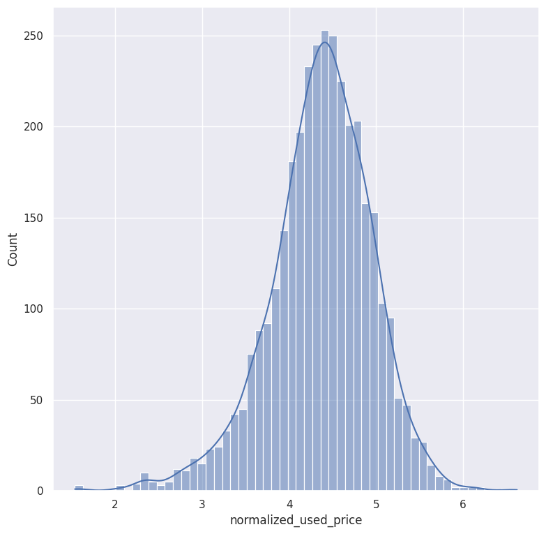

```python
plt.figure(figsize=(9, 9))
sns.histplot(data = ReCell, x = 'normalized_used_price', kde=True)
plt.show()
```

Normalized used prices has a normal distribution with outliers to the left and right

```python
#What percentage of the used device market is dominated by Android devices?
used_os = ReCell.groupby(['os']) [['normalized_used_price']].sum()
print(used_os)
```

```
         normalized_used_price
os
Android           14165.930292
Others              452.998087
Windows             278.352655
iOS                 178.434488
```

```python
#What percentage of the used device market is dominated by Android devices?
ReCell.groupby(["os"])\
.agg({"normalized_used_price" : "sum"})[["normalized_used_price"]]\
.apply(lambda x: 100*x/x.sum())\
.sort_values(by="normalized_used_price", ascending=False)
```

| os | normalized_used_price |
| --- | --- |
| Android | 93.965227 |
| Others | 3.004820 |
| Windows | 1.846364 |
| iOS | 1.183589 |

Android represents 94% of the Used Price market.

## The amount of RAM is important for the smooth functioning of a device. How does the amount of RAM vary with the brand?

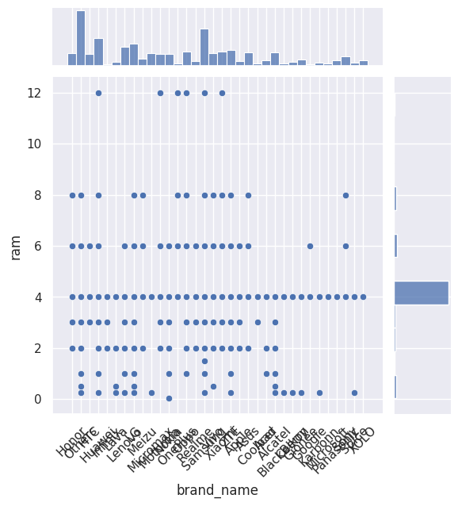

```python
plt.figure(figsize=(50, 50))
sns.jointplot(x ='brand_name', y ='ram', data = ReCell)
plt.xticks(rotation=45);
```

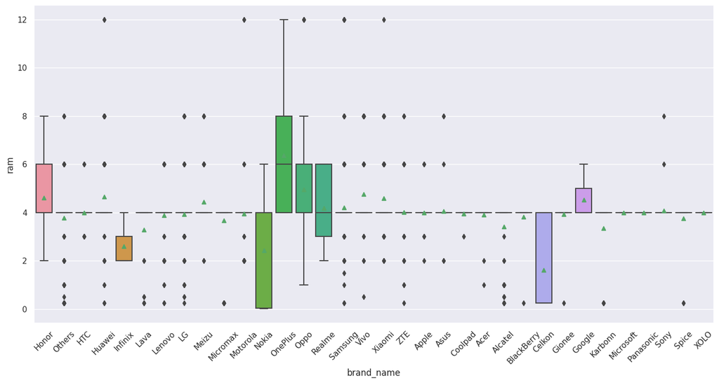

```python
# complete the code to visually plot the time spent on the new page for different language users
plt.figure(figsize=(17,8))
sns.boxplot(x = 'brand_name', y = 'ram', showmeans = True, data = ReCell)
plt.xticks(rotation=45);
plt.show()
```

Ram varies between close to zero and 12GB. 4GB of Ram appears to be represented accross all brands. The of the 34 represented brands, the ones with the highest availibility for consumers are Huawei, Motorola, OnePlue, Opp, Samsung, and Xiaomi topping out at 12GB. 8 other brands top out at 8GB of Ram (Honor, Others, LG, Meizu, Vivo, ZTE, Asus, and Sony).

## A large battery often increases a device's weight, making it feel uncomfortable in the hands. How does the weight vary for phones and tablets offering large batteries (more than 4500 mAh)?

```python
# Total number of batteries 4500mAH or higher
battery_greater_than_4500 = ReCell[ReCell['battery']>4500]
# Calculate the number of total delivery times over 60 minutes
print('The total number of batteries 4500mAH or higher is:', battery_greater_than_4500.shape[0])
```

```
The total number of batteries 4500mAH or higher is: 341
```

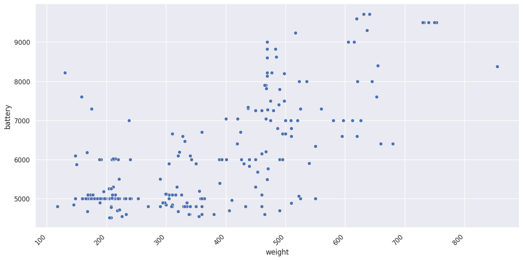

```python
battery_greater_than_4500 = ReCell.loc[ReCell['battery'] > 4500 ]
plt.figure(figsize=(15, 7))
sns.scatterplot(x='weight', y ='battery', data=battery_greater_than_4500)
plt.xticks(rotation=45,
           ha='right');
```

The weight varies between 125 grams to 850 grams or 4.4 oz to 1.13 pounds, which probably starts with phones and trasitions to tablets. Tablets are larger than phones so consumers should anticipate thoses devices weighting more.

## Bigger screens are desirable for entertainment purposes as they offer a better viewing experience. How many phones and tablets are available across different brands with a screen size larger than 6 inches?

```python
screen_greater_than_6 = ReCell[ReCell['screen_size']>6]
screen_greater_than_6.shape[0]
```

```
3362
```

## A lot of devices nowadays offer great selfie cameras, allowing us to capture our favorite moments with loved ones. What is the distribution of devices offering greater than 8MP selfie cameras across brands?

```python
# Total number of selfie_camera_mp higher than 8
selfie_greater_than_6 = ReCell[ReCell['selfie_camera_mp']>8]
# Calculate the number of selfie_camera_mp higher than 8
print('The total number of selfie_camera_mp higher than 8 is:', selfie_greater_than_6.shape[0])
```

```
The total number of selfie_camera_mp higher than 8 is: 655
```

Approx ~ 20% of all devices have cameras larger than 8mp

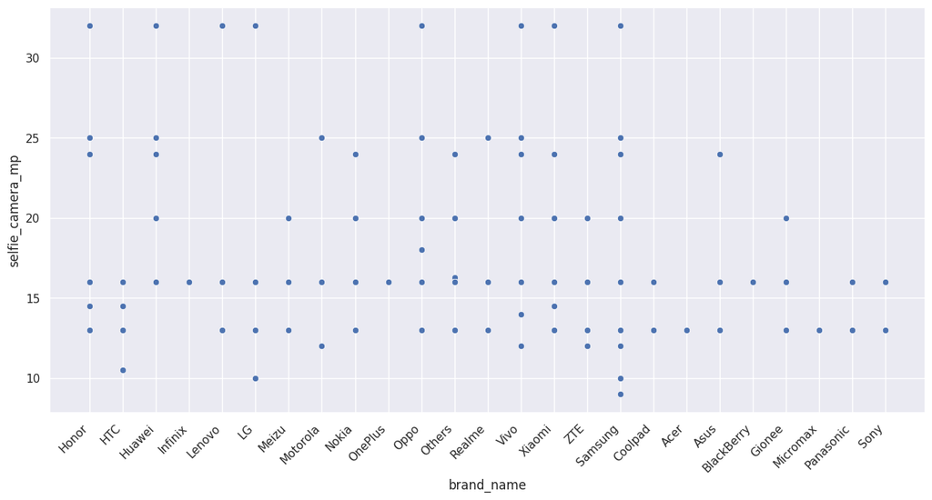

```python
# conditioning plot on the basis of continuous variables
ReCell_3 = ReCell.loc[ReCell['selfie_camera_mp'] > 8 ]
plt.figure(figsize=(15, 7))
sns.scatterplot(x='brand_name', y ='selfie_camera_mp', data=ReCell_3)
plt.xticks(rotation=45,
           ha='right');
```

The distribution ranging 9-32 mp, is almost entriey Android Brands, which correlates with used devices being 93%.

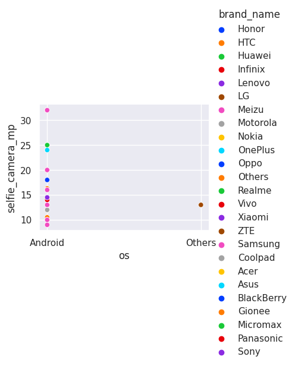

```python
sns.relplot(
    x='os',
    y='selfie_camera_mp',
    data=ReCell_3,
    palette='bright',
    height=3, aspect=1.3,
    kind='scatter',
    hue='brand_name')
```

The distribution ranging 9-32 mp, is almost entriey Android Brands, which correlates with used devices being 93%.

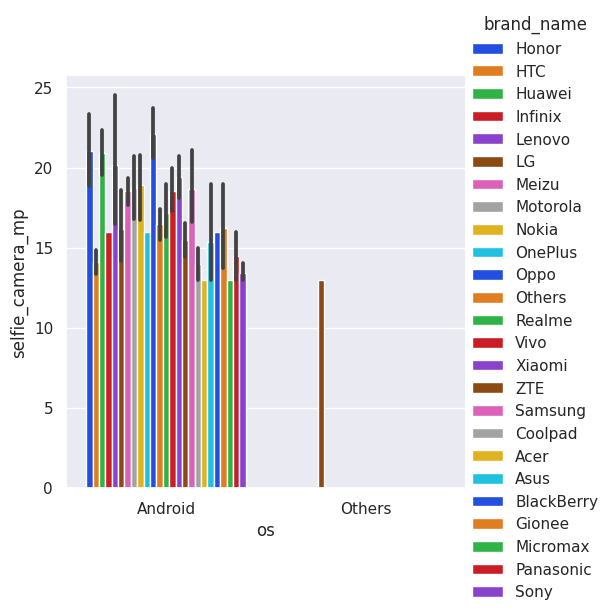

```python
sns.catplot(
    x='os',
    y='selfie_camera_mp',
    data=ReCell_3,
    palette='bright',
    kind='bar',
    hue='brand_name')
```

The distribution is almost entriey Android Brands, which correlates with used devices being 93%.

## Which attributes are highly correlated with the normalized price of a used device?

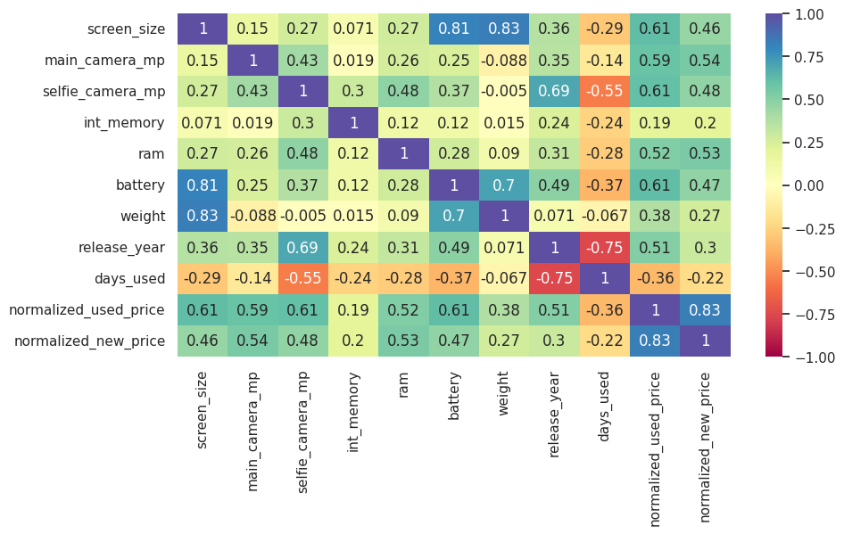

```python
plt.figure(figsize=(10,5))
sns.heatmap(ReCell.corr(),annot=True,cmap='Spectral',vmin=-1,vmax=1)
plt.show()
```

Feature higly correlated with normalized used price:

- normalized_new_price is .83

Features that are moderately correlated with normalized used price:

- screen size is .61
- battery is .61
- selfie camera mp .61
- main camera mp .59

## Data Preprocessing

- Missing value treatment
- Feature engineering (if needed)
- Outlier detection and treatment (if needed)
- Preparing data for modeling
- Any other preprocessing steps (if needed)

# Missing Value Treatment

```python
ReCell.isnull().sum()
```

```
brand_name                 0
os                         0
screen_size                0
4g                         0
5g                         0
main_camera_mp           179
selfie_camera_mp           2
int_memory                 4
ram                        4
battery                    6
weight                     7
release_year               0
days_used                  0
normalized_used_price      0
normalized_new_price       0
dtype: int64
```

Let's fix the missing values in the data.

```python
# checking column medians
ReCell.median()
```

```
screen_size                12.830000
main_camera_mp              8.000000
selfie_camera_mp            5.000000
int_memory                 32.000000
ram                         4.000000
battery                  3000.000000
weight                    160.000000
release_year             2015.500000
days_used                 690.500000
normalized_used_price       4.405133
normalized_new_price        5.245892
dtype: float64
```

```python
# we first create a copy of the data to avoid changes to it
ReCell_1 = ReCell.copy()
```

```python
from numpy.ma.extras import median
ReCell_1.fillna({"ram":ReCell_1['ram'].median(), "main_camera_mp":ReCell_1['main_camera_mp'].median(),"selfie_camera_mp": ReCell_1['selfie_camera_mp'].median(),"int_memory": ReCell_1['int_memory'].median(), 'battery': ReCell_1['battery'].median, 'weight': ReCell_1['weight'].median},inplace=True)
```

```python
ReCell_1.isnull().sum()
```

```
brand_name               0
os                       0
screen_size              0
4g                       0
5g                       0
main_camera_mp           0
selfie_camera_mp         0
int_memory               0
ram                      0
battery                  0
weight                   0
release_year             0
days_used                0
normalized_used_price    0
normalized_new_price     0
dtype: int64
```

```python
ReCell_1.info()
```

```
<class 'pandas.core.frame.DataFrame'>
RangeIndex: 3454 entries, 0 to 3453
Data columns (total 15 columns):
 #   Column                 Non-Null Count  Dtype
---  ------                 --------------  -----
 0   brand_name             3454 non-null   object
 1   os                     3454 non-null   object
 2   screen_size            3454 non-null   float64
 3   4g                     3454 non-null   object
 4   5g                     3454 non-null   object
 5   main_camera_mp         3454 non-null   float64
 6   selfie_camera_mp       3454 non-null   float64
 7   int_memory             3454 non-null   float64
 8   ram                    3454 non-null   float64
 9   battery                3454 non-null   object
 10  weight                 3454 non-null   object
 11  release_year           3454 non-null   int64
 12  days_used              3454 non-null   int64
 13  normalized_used_price  3454 non-null   float64
 14  normalized_new_price   3454 non-null   float64
dtypes: float64(7), int64(2), object(6)
memory usage: 404.9+ KB
```

```python
ReCell_1['weight'].fillna(0, inplace=False)
```

```
0       146.0
1       213.0
2       213.0
3       480.0
4       185.0
        ...
3449    190.0
3450    200.0
3451    165.0
3452    160.0
3453    168.0
Name: weight, Length: 3454, dtype: object
```

```python
ReCell_1['battery'].fillna(0, inplace=False)
```

```
0       3020.0
1       4300.0
2       4200.0
3       7250.0
4       5000.0
         ...
3449    5000.0
3450    4000.0
3451    4000.0
3452    4000.0
3453    4000.0
Name: battery, Length: 3454, dtype: object
```

```python
ReCell_1['weight'] = pd.to_numeric(ReCell_1['weight'], errors='coerce')
```

```python
ReCell_1['battery'] = pd.to_numeric(ReCell_1['battery'], errors='coerce')
```

```python
ReCell_1.info()
```

```
<class 'pandas.core.frame.DataFrame'>
RangeIndex: 3454 entries, 0 to 3453
Data columns (total 15 columns):
 #   Column                 Non-Null Count  Dtype
---  ------                 --------------  -----
 0   brand_name             3454 non-null   object
 1   os                     3454 non-null   object
 2   screen_size            3454 non-null   float64
 3   4g                     3454 non-null   object
 4   5g                     3454 non-null   object
 5   main_camera_mp         3454 non-null   float64
 6   selfie_camera_mp       3454 non-null   float64
 7   int_memory             3454 non-null   float64
 8   ram                    3454 non-null   float64
 9   battery                3448 non-null   float64
 10  weight                 3447 non-null   float64
 11  release_year           3454 non-null   int64
 12  days_used              3454 non-null   int64
 13  normalized_used_price  3454 non-null   float64
 14  normalized_new_price   3454 non-null   float64
dtypes: float64(9), int64(2), object(4)
memory usage: 404.9+ KB
```

```python
ReCell_1.isna().sum()
```

```
brand_name               0
os                       0
screen_size              0
4g                       0
5g                       0
main_camera_mp           0
selfie_camera_mp         0
int_memory               0
ram                      0
battery                  6
weight                   7
release_year             0
days_used                0
normalized_used_price    0
normalized_new_price     0
dtype: int64
```

```python
ReCell_1 = ReCell_1.fillna(ReCell_1.median())
```

```python
ReCell_1.isna().sum()
```

```
brand_name               0
os                       0
screen_size              0
4g                       0
5g                       0
main_camera_mp           0
selfie_camera_mp         0
int_memory               0
ram                      0
battery                  0
weight                   0
release_year             0
days_used                0
normalized_used_price    0
normalized_new_price     0
dtype: int64
```

### Feature Engineering

- Let's create a new feature `years` by taking the difference between 2021 and `release_year` columns
- We will drop the original columns once the new feature is created as the year values themselves are not numerical in nature

```python
ReCell_1.release_year.unique()
```

```
array([2020, 2019, 2013, 2014, 2016, 2018, 2015, 2017])
```

```python
ReCell_1["years"] = 2021 - ReCell_1["release_year"]
ReCell_1.drop(["release_year"], axis=1, inplace=True)
ReCell_1.head()
```

|  | brand_name | os | screen_size | 4g | 5g | main_camera_mp | selfie_camera_mp | int_memory | ram | battery | weight | days_used | normalized_used_price | normalized_new_price | years |
| --- | --- | --- | --- | --- | --- | --- | --- | --- | --- | --- | --- | --- | --- | --- | --- |
| 0 | Honor | Android | 14.50 | yes | no | 13.0 | 5.0 | 64.0 | 3.0 | 3020.0 | 146.0 | 127 | 4.307572 | 4.715100 | 1 |
| 1 | Honor | Android | 17.30 | yes | yes | 13.0 | 16.0 | 128.0 | 8.0 | 4300.0 | 213.0 | 325 | 5.162097 | 5.519018 | 1 |
| 2 | Honor | Android | 16.69 | yes | yes | 13.0 | 8.0 | 128.0 | 8.0 | 4200.0 | 213.0 | 162 | 5.111084 | 5.884631 | 1 |
| 3 | Honor | Android | 25.50 | yes | yes | 13.0 | 8.0 | 64.0 | 6.0 | 7250.0 | 480.0 | 345 | 5.135387 | 5.630961 | 1 |
| 4 | Honor | Android | 15.32 | yes | no | 13.0 | 8.0 | 64.0 | 3.0 | 5000.0 | 185.0 | 293 | 4.389995 | 4.947837 | 1 |

```python
ReCell_1.info()
```

```
<class 'pandas.core.frame.DataFrame'>
RangeIndex: 3454 entries, 0 to 3453
Data columns (total 15 columns):
 #   Column                 Non-Null Count  Dtype
---  ------                 --------------  -----
 0   brand_name             3454 non-null   object
 1   os                     3454 non-null   object
 2   screen_size            3454 non-null   float64
 3   4g                     3454 non-null   object
 4   5g                     3454 non-null   object
 5   main_camera_mp         3454 non-null   float64
 6   selfie_camera_mp       3454 non-null   float64
 7   int_memory             3454 non-null   float64
 8   ram                    3454 non-null   float64
 9   battery                3454 non-null   float64
 10  weight                 3454 non-null   float64
 11  days_used              3454 non-null   int64
 12  normalized_used_price  3454 non-null   float64
 13  normalized_new_price   3454 non-null   float64
 14  years                  3454 non-null   int64
dtypes: float64(9), int64(2), object(4)
memory usage: 404.9+ KB
```

# Outlier Detection and Treatment

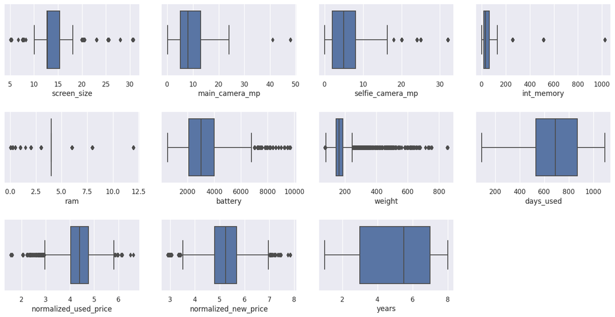

```python
# outlier detection using boxplot
num_cols = ReCell_1.select_dtypes(include=np.number).columns.tolist()

plt.figure(figsize=(15, 10))

for i, variable in enumerate(num_cols):
    plt.subplot(4, 4, i + 1)
    sns.boxplot(data=ReCell_1, x=variable)
    plt.tight_layout(pad=2)

plt.show()
```

- There are quite a few outliers in the data
- However, we will not treat them as they are proper values

# EDA

- It is a good idea to explore the data once again after manipulating it.

```python
def histogram_boxplot(data, feature, figsize=(15, 10), kde=False, bins=None):
    """
    Boxplot and histogram combined

    data: dataframe
    feature: dataframe column
    figsize: size of figure (default (15,10))
    kde: whether to show the density curve (default False)
    bins: number of bins for histogram (default None)
    """
    f2, (ax_box2, ax_hist2) = plt.subplots(
        nrows=2,  # Number of rows of the subplot grid= 2
        sharex=True,  # x-axis will be shared among all subplots
        gridspec_kw={"height_ratios": (0.25, 0.75)},
        figsize=figsize,
    )  # creating the 2 subplots
    sns.boxplot(
        data=data, x=feature, ax=ax_box2, showmeans=True, color="violet"
    )  # boxplot will be created and a triangle will indicate the mean value of the column
    sns.histplot(
        data=data, x=feature, kde=kde, ax=ax_hist2, bins=bins
    ) if bins else sns.histplot(
        data=data, x=feature, kde=kde, ax=ax_hist2
    )  # For histogram
    ax_hist2.axvline(
        data[feature].mean(), color="green", linestyle="--"
    )  # Add mean to the histogram
    ax_hist2.axvline(
        data[feature].median(), color="black", linestyle="-"
    )  # Add median to the histogram
```

```python
# function to create labeled barplots


def labeled_barplot(data, feature, perc=False, n=None):
    """
    Barplot with percentage at the top

    data: dataframe
    feature: dataframe column
    perc: whether to display percentages instead of count (default is False)
    n: displays the top n category levels (default is None, i.e., display all levels)
    """

    total = len(data[feature])  # length of the column
    count = data[feature].nunique()
    if n is None:
        plt.figure(figsize=(count + 2, 6))
    else:
        plt.figure(figsize=(n + 2, 6))

    plt.xticks(rotation=90, fontsize=15)
    ax = sns.countplot(
        data=data,
        x=feature,
        palette="Paired",
        order=data[feature].value_counts().index[:n],
    )

    for p in ax.patches:
        if perc == True:
            label = "{:.1f}%".format(
                100 * p.get_height() / total
            )  # percentage of each class of the category
        else:
            label = p.get_height()  # count of each level of the category

        x = p.get_x() + p.get_width() / 2  # width of the plot
        y = p.get_height()  # height of the plot

        ax.annotate(
            label,
            (x, y),
            ha="center",
            va="center",
            size=12,
            xytext=(0, 5),
            textcoords="offset points",
        )  # annotate the percentage

    plt.show()  # show the plot
```

```python
ReCell_1.columns
```

```
Index(['brand_name', 'os', 'screen_size', '4g', '5g', 'main_camera_mp',
       'selfie_camera_mp', 'int_memory', 'ram', 'battery', 'weight',
       'days_used', 'normalized_used_price', 'normalized_new_price', 'years'],
      dtype='object')
```

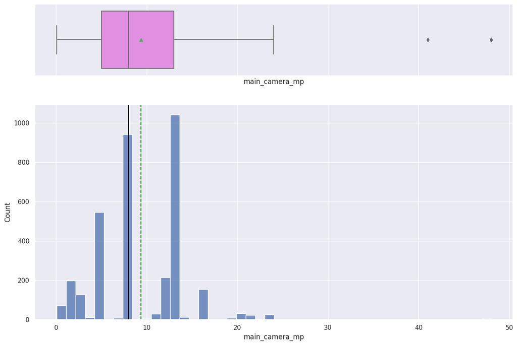

```python
histogram_boxplot(ReCell_1, "main_camera_mp")
```

Main Camera MP is not a Normal Distribution

- The distribution for main_camera_mp is not symetrical and contains multple modes.
- Most of the devices seem to peak at 5, 8, 13 mp as these seem to be the popular chioces for buyers. Cameras exceeding 13 mp are not as well represented, which could mean cost played a role.

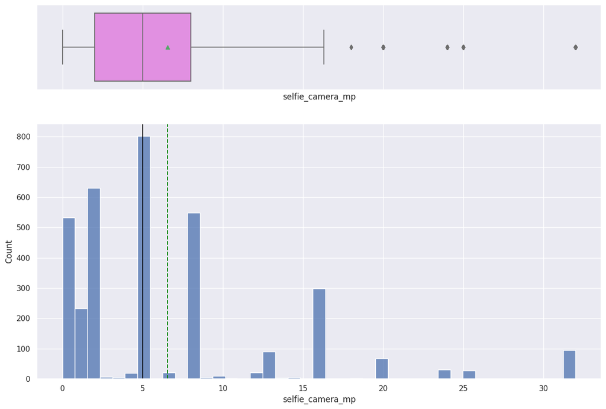

```python
histogram_boxplot(ReCell_1, "selfie_camera_mp")
```

Selfie Camera MP is not a Normal Distribution

- The distribution for selfie_camera_mp is not symetrical and contains multple modes.
- Most of the devices seem to peak at 1-3, 5, 8 mp as these seem to be the popular chioces for buyers. 15 mp also has a peak at around 300 devices. Cameras exceeding 8 mp are not as well represented, which could mean cost played a role.

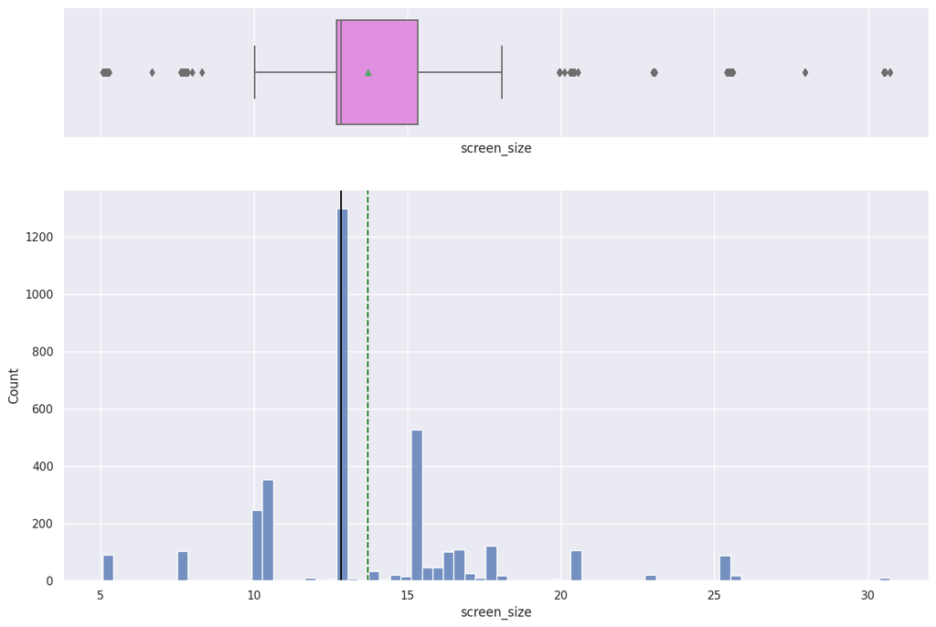

```python
histogram_boxplot(ReCell_1, "screen_size")
```

Screen_size looks like a Normal Distribution minus the areas where there are no screen sizes.

- The distribution for screen_size is sort of symetrical.
- Most of the devices have anywhere from a size of 6-32.

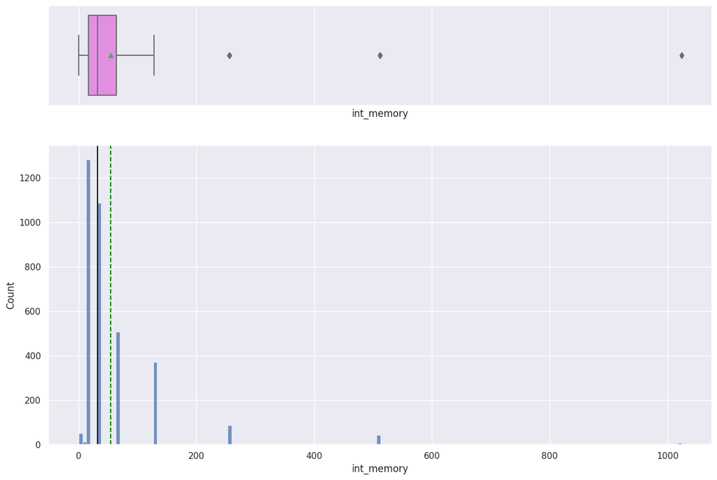

```python
histogram_boxplot(ReCell_1, "int_memory")
```

The int_memory is right skewed with some outliers most of the memory is represented between 0-150 GB.

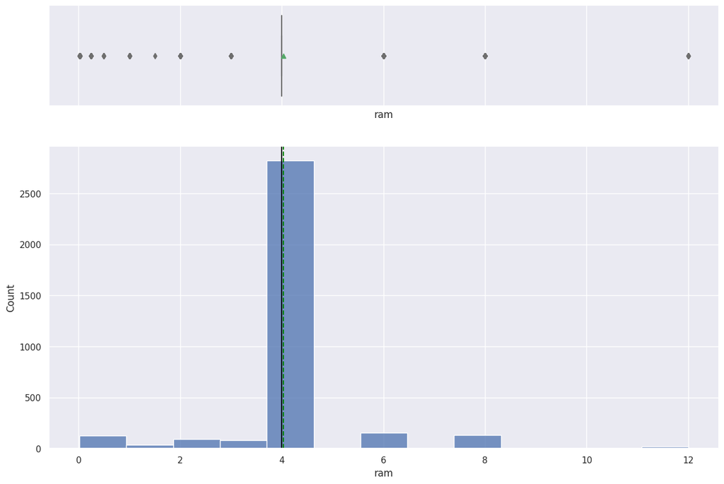

```python
histogram_boxplot(ReCell_1, "ram")
```

Ram is not a normal distribution as nearly 80% of all devices are 4GB.

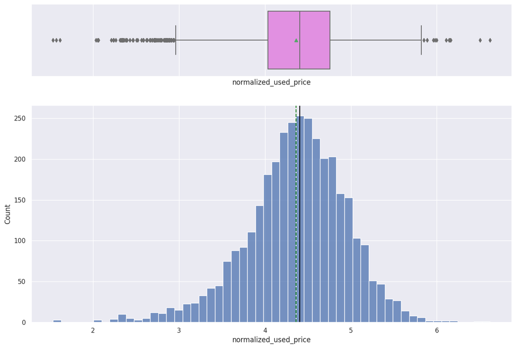

```python
histogram_boxplot(ReCell_1, "normalized_used_price")
```

Normalized used price is a Normal Distribution with outliers to the left and right of the distribution

Most of the prices seems to be between 3.5 and 5.5.

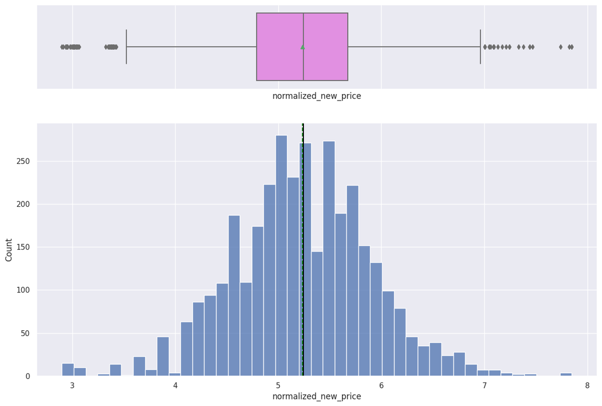

```python
histogram_boxplot(ReCell_1, "normalized_new_price")
```

Normalized new price is an almost Normal Distribution

Most of the prices seems to be between 4.5 and 6.5.

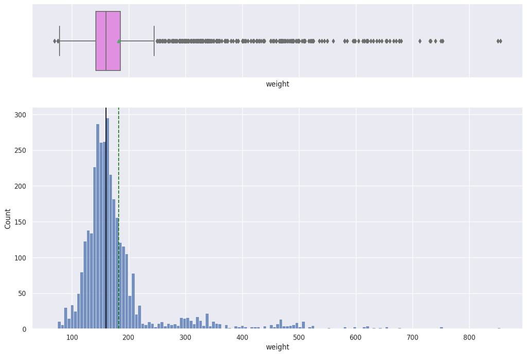

```python
histogram_boxplot(ReCell_1, "weight")
```

Weight is an almost Normal Distribution with an extremly long right tail

- Most of the weights of all purchased devices seems to be between 50 and 225 grams.
- Devices weightings more than 225 grams seems to not be purchased as often as the lighter devices. Which could point to a tablet purchase.

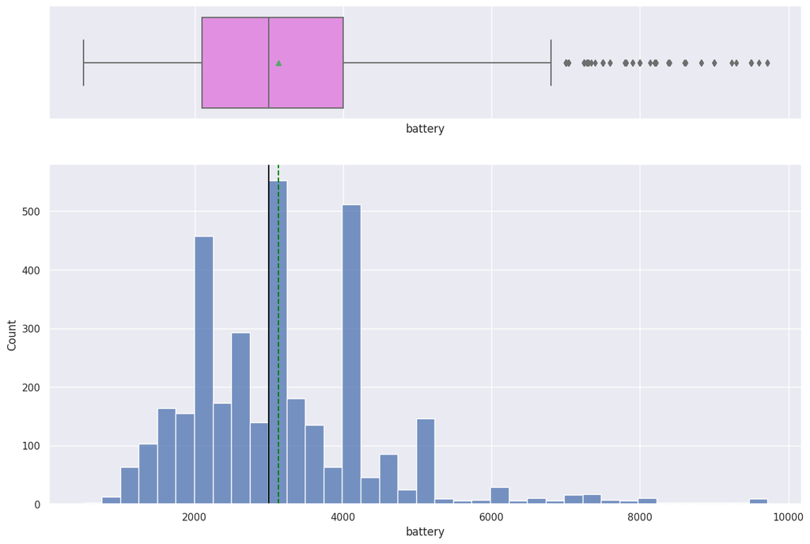

```python
histogram_boxplot(ReCell_1, "battery")
```

Battery is not a Normal Distribution

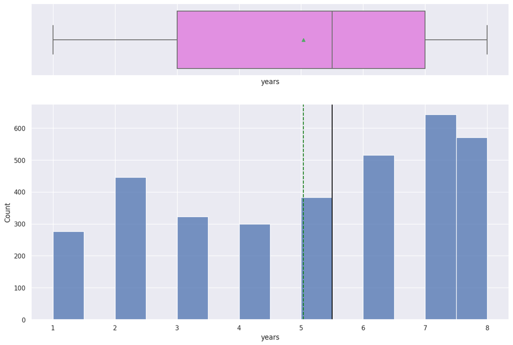

```python
histogram_boxplot(ReCell_1, "years")
```

Years is not a normal distribution

- Devices range from 1-8 years if age
- As expected the older the device the greater the availibility, but also might not be as desirable as newly devices have better functionality

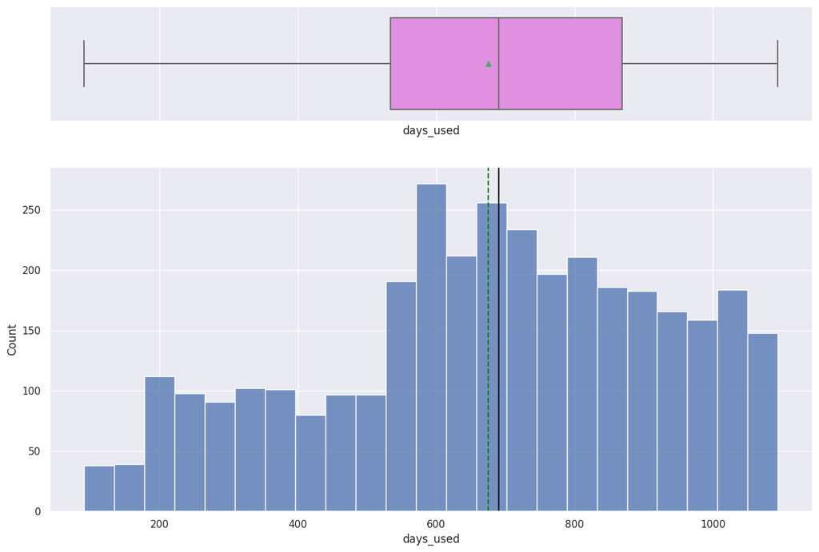

```python
histogram_boxplot(ReCell_1, "days_used")
```

Days_used is not a normal distribution

- Depends on the market
- depending on the popularity of the device plays a factor

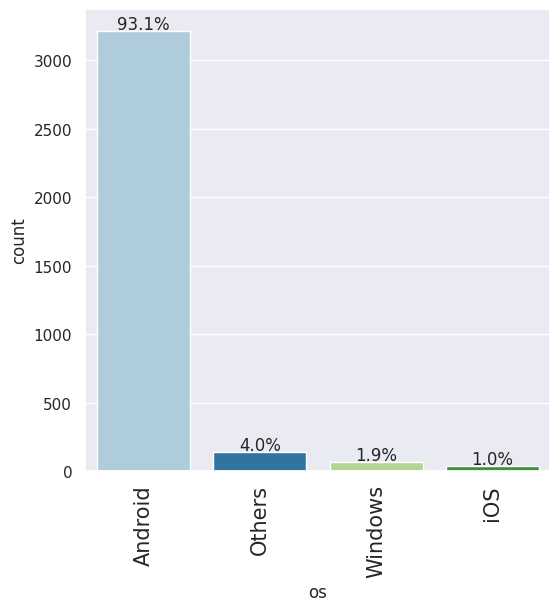

```python
labeled_barplot(ReCell_1, "os", perc=True)
```

OS does not have a normal distribution

- Android dominates 93% of the market

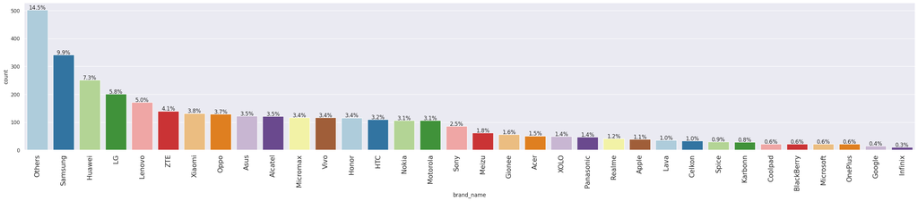

```python
labeled_barplot(ReCell_1, "brand_name", perc=True)
```

Brand_name is a right skewed distribution.

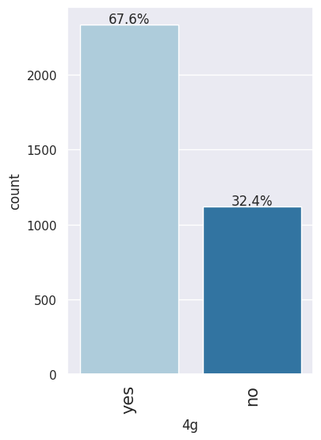

```python
labeled_barplot(ReCell_1, "4g", perc=True)
```

This is older technology and there are more in circulation so the company may not profit as much, especially for older devices

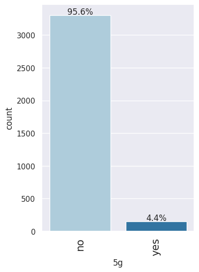

```python
labeled_barplot(ReCell_1, "5g", perc=True)
```

Very new device not alot in circulation so the company can charge more

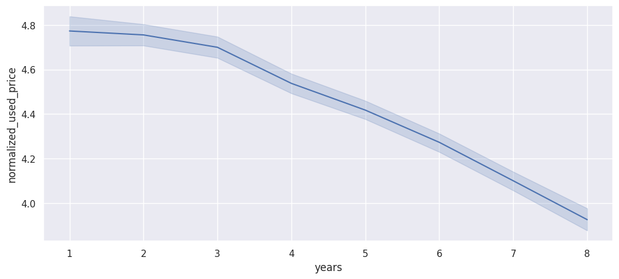

```python
plt.figure(figsize=(12, 5))
sns.lineplot(ReCell_1, x='years', y='normalized_used_price')
plt.show()
```

The older the device the less the company can recieve in revenue

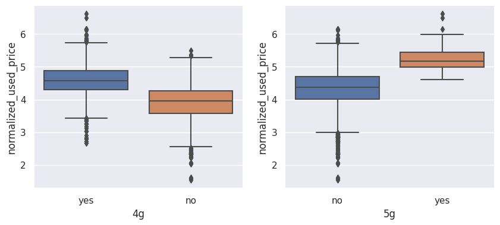

```python
plt.figure(figsize=(10, 4))

plt.subplot(121)
sns.boxplot(data=ReCell_1, x="4g", y="normalized_used_price")

plt.subplot(122)
sns.boxplot(data=ReCell_1, x="5g", y="normalized_used_price")

plt.show()
```

In both types of device people preferred 4g & 5g, prices are higher for these types of devices

# Data Preparation for Modeling

- We want to predict a dynamic pricing strategy for used and refurbished devices
- Before we proceed to build a model, we'll have to encode categorical features
- We'll split the data into train and test to be able to evaluate the model that we build on the train data
- We will build a Linear Regression model using the train data and then check it's performance

```python
# defining X and y variables
X = ReCell_1.drop(["normalized_used_price"], axis=1)
y = ReCell_1["normalized_used_price"]

print(X.head())
print(y.head())
```

```
  brand_name       os  screen_size   4g   5g  main_camera_mp  \
0      Honor  Android        14.50  yes   no            13.0
1      Honor  Android        17.30  yes  yes            13.0
2      Honor  Android        16.69  yes  yes            13.0
3      Honor  Android        25.50  yes  yes            13.0
4      Honor  Android        15.32  yes   no            13.0

   selfie_camera_mp  int_memory  ram  battery  weight  days_used  \
0               5.0        64.0  3.0   3020.0   146.0        127
1              16.0       128.0  8.0   4300.0   213.0        325
2               8.0       128.0  8.0   4200.0   213.0        162
3               8.0        64.0  6.0   7250.0   480.0        345
4               8.0        64.0  3.0   5000.0   185.0        293

   normalized_new_price  years
0              4.715100      1
1              5.519018      1
2              5.884631      1
3              5.630961      1
4              4.947837      1
0    4.307572
1    5.162097
2    5.111084
3    5.135387
4    4.389995
Name: normalized_used_price, dtype: float64
```

```python
# let's add the intercept to data
X = sm.add_constant(X)
```

```python
# creating dummy variables
X = pd.get_dummies(
    X,
    columns=X.select_dtypes(include=["object", "category"]).columns.tolist(),
    drop_first=True,
)
X.head()
```

|  | const | screen_size | main_camera_mp | selfie_camera_mp | int_memory | ram | battery | weight | days_used | normalized_new_price | ... | brand_name_Spice | brand_name_Vivo | brand_name_XOLO | brand_name_Xiaomi | brand_name_ZTE | os_Others | os_Windows | os_iOS | 4g_yes | 5g_yes |
| --- | --- | --- | --- | --- | --- | --- | --- | --- | --- | --- | --- | --- | --- | --- | --- | --- | --- | --- | --- | --- | --- |
| 0 | 1.0 | 14.50 | 13.0 | 5.0 | 64.0 | 3.0 | 3020.0 | 146.0 | 127 | 4.715100 | ... | 0 | 0 | 0 | 0 | 0 | 0 | 0 | 0 | 1 | 0 |
| 1 | 1.0 | 17.30 | 13.0 | 16.0 | 128.0 | 8.0 | 4300.0 | 213.0 | 325 | 5.519018 | ... | 0 | 0 | 0 | 0 | 0 | 0 | 0 | 0 | 1 | 1 |
| 2 | 1.0 | 16.69 | 13.0 | 8.0 | 128.0 | 8.0 | 4200.0 | 213.0 | 162 | 5.884631 | ... | 0 | 0 | 0 | 0 | 0 | 0 | 0 | 0 | 1 | 1 |
| 3 | 1.0 | 25.50 | 13.0 | 8.0 | 64.0 | 6.0 | 7250.0 | 480.0 | 345 | 5.630961 | ... | 0 | 0 | 0 | 0 | 0 | 0 | 0 | 0 | 1 | 1 |
| 4 | 1.0 | 15.32 | 13.0 | 8.0 | 64.0 | 3.0 | 5000.0 | 185.0 | 293 | 4.947837 | ... | 0 | 0 | 0 | 0 | 0 | 0 | 0 | 0 | 1 | 0 |

5 rows × 49 columns

```python
# splitting the data in 70:30 ratio for train to test data

x_train, x_test, y_train, y_test = train_test_split(X, y, test_size=0.3, random_state=1)
```

```python
print("Number of rows in train data =", x_train.shape[0])
print("Number of rows in test data =", x_test.shape[0])
```

```
Number of rows in train data = 2417
Number of rows in test data = 1037
```

```python
ReCell_1.isna().sum()
```

```
brand_name               0
os                       0
screen_size              0
4g                       0
5g                       0
main_camera_mp           0
selfie_camera_mp         0
int_memory               0
ram                      0
battery                  0
weight                   0
days_used                0
normalized_used_price    0
normalized_new_price     0
years                    0
dtype: int64
```

## Model Building - Linear Regression

```python
olsmodel = sm.OLS(y_train, x_train).fit()
print(olsmodel.summary())
```

```
                              OLS Regression Results
=================================================================================
Dep. Variable:     normalized_used_price   R-squared:                       0.845
Model:                               OLS   Adj. R-squared:                  0.842
Method:                    Least Squares   F-statistic:                     268.8
Date:                   Sat, 15 Apr 2023   Prob (F-statistic):               0.00
Time:                           00:17:43   Log-Likelihood:                 124.22
No. Observations:                   2417   AIC:                            -150.4
Df Residuals:                       2368   BIC:                             133.3
Df Model:                             48
Covariance Type:               nonrobust
=========================================================================================
                            coef    std err          t      P>|t|      [0.025      0.975]
-----------------------------------------------------------------------------------------
const                     1.3286      0.071     18.604      0.000       1.189       1.469
screen_size               0.0243      0.003      7.145      0.000       0.018       0.031
main_camera_mp            0.0203      0.001     13.806      0.000       0.017       0.023
selfie_camera_mp          0.0136      0.001     12.084      0.000       0.011       0.016
int_memory                0.0001   6.97e-05      1.542      0.123   -2.92e-05       0.000
ram                       0.0239      0.005      4.657      0.000       0.014       0.034
battery               -1.585e-05   7.27e-06     -2.181      0.029   -3.01e-05    -1.6e-06
weight                    0.0010      0.000      7.421      0.000       0.001       0.001
days_used              3.485e-05   3.09e-05      1.127      0.260   -2.58e-05    9.55e-05
normalized_new_price      0.4310      0.012     35.133      0.000       0.407       0.455
years                    -0.0248      0.005     -5.441      0.000      -0.034      -0.016
brand_name_Alcatel        0.0153      0.048      0.321      0.748      -0.078       0.109
brand_name_Apple         -0.0116      0.147     -0.079      0.937      -0.300       0.277
brand_name_Asus           0.0195      0.048      0.408      0.683      -0.074       0.113
brand_name_BlackBerry    -0.0295      0.070     -0.420      0.675      -0.167       0.108
brand_name_Celkon        -0.0424      0.066     -0.640      0.522      -0.172       0.088
brand_name_Coolpad        0.0401      0.073      0.551      0.582      -0.103       0.183
brand_name_Gionee         0.0454      0.058      0.787      0.431      -0.068       0.159
brand_name_Google        -0.0312      0.085     -0.369      0.712      -0.197       0.135
brand_name_HTC           -0.0115      0.048     -0.240      0.811      -0.106       0.083
brand_name_Honor          0.0244      0.049      0.496      0.620      -0.072       0.121
brand_name_Huawei        -0.0081      0.044     -0.181      0.856      -0.095       0.079
brand_name_Infinix        0.1548      0.093      1.661      0.097      -0.028       0.337
brand_name_Karbonn        0.0971      0.067      1.447      0.148      -0.034       0.229
brand_name_LG            -0.0152      0.045     -0.335      0.738      -0.104       0.074
brand_name_Lava           0.0337      0.062      0.541      0.589      -0.089       0.156
```

[output cut: 19 more lines]

```
os_Windows               -0.0176      0.045     -0.389      0.697      -0.106       0.071
os_iOS                   -0.0585      0.146     -0.399      0.690      -0.346       0.229
4g_yes                    0.0507      0.016      3.190      0.001       0.020       0.082
5g_yes                   -0.0435      0.032     -1.369      0.171      -0.106       0.019
==============================================================================
Omnibus:                      217.620   Durbin-Watson:                   1.904
Prob(Omnibus):                  0.000   Jarque-Bera (JB):              409.702
Skew:                          -0.607   Prob(JB):                     1.08e-89
Kurtosis:                       4.611   Cond. No.                     1.78e+05
==============================================================================

Notes:
[1] Standard Errors assume that the covariance matrix of the errors is correctly specified.
[2] The condition number is large, 1.78e+05. This might indicate that there are
strong multicollinearity or other numerical problems.
```

## Model Performance Check

Let's check the performance of the model using different metrics.

- We will be using metric functions defined in sklearn for RMSE, MAE, and $R^2$.
- We will define a function to calculate MAPE and adjusted $R^2$.
  - The mean absolute percentage error (MAPE) measures the accuracy of predictions as a percentage, and can be calculated as the average absolute percent error for each predicted value minus actual values divided by actual values. It works best if there are no extreme values in the data and none of the actual values are 0.
- We will create a function which will print out all the above metrics in one go.

```python
# function to compute adjusted R-squared
def adj_r2_score(predictors, targets, predictions):
    r2 = r2_score(targets, predictions)
    n = predictors.shape[0]
    k = predictors.shape[1]
    return 1 - ((1 - r2) * (n - 1) / (n - k - 1))


# function to compute MAPE
def mape_score(targets, predictions):
    return np.mean(np.abs(targets - predictions) / targets) * 100


# function to compute different metrics to check performance of a regression model
def model_performance_regression(model, predictors, target):
    """
    Function to compute different metrics to check regression model performance

    model: regressor
    predictors: independent variables
    target: dependent variable
    """

    # predicting using the independent variables
    pred = model.predict(predictors)

    r2 = r2_score(target, pred)  # to compute R-squared
    adjr2 = adj_r2_score(predictors, target, pred)  # to compute adjusted R-squared
    rmse = np.sqrt(mean_squared_error(target, pred))  # to compute RMSE
    mae = mean_absolute_error(target, pred)  # to compute MAE
    mape = mape_score(target, pred)  # to compute MAPE

    # creating a dataframe of metrics
    ReCell_1_perf = pd.DataFrame(
        {
            "RMSE": rmse,
            "MAE": mae,
            "R-squared": r2,
            "Adj. R-squared": adjr2,
            "MAPE": mape,
        },
        index=[0],
    )

    return ReCell_1_perf
```

```python
# checking model performance on train set (seen 70% data)
print("Training Performance\n")
olsmodel_train_perf = model_performance_regression(olsmodel, x_train, y_train)
olsmodel_train_perf
```

```
Training Performance
```

|  | RMSE | MAE | R-squared | Adj. R-squared | MAPE |
| --- | --- | --- | --- | --- | --- |
| 0 | 0.229849 | 0.180336 | 0.844933 | 0.841723 | 4.326958 |

```python
# checking model performance on test set (seen 30% data)
print("Test Performance\n")
olsmodel_test_perf = model_performance_regression(olsmodel, x_test, y_test) ## Complete the code to check the performance on test data
olsmodel_test_perf
```

```
Test Performance
```

|  | RMSE | MAE | R-squared | Adj. R-squared | MAPE |
| --- | --- | --- | --- | --- | --- |
| 0 | 0.238306 | 0.184064 | 0.842547 | 0.834731 | 4.488006 |

## Checking Linear Regression Assumptions

We will be checking the following Linear Regression assumptions:

1. **No Multicollinearity**
2. **Linearity of variables**
3. **Independence of error terms**
4. **Normality of error terms**
5. **No Heteroscedasticity**

### TEST FOR MULTICOLLINEARITY

Multicollinearity occurs when predictor variables in a regression model are correlated. This correlation is a problem because predictor variables should be independent. If the correlation between variables is high, it can cause problems when we fit the model and interpret the results. When we have multicollinearity in the linear model, the coefficients that the model suggests are unreliable.

- There are different ways of detecting (or testing) multicollinearity. One such way is by using the Variance Inflation Factor, or VIF.
- **Variance Inflation Factor (VIF)**: Variance inflation factors measure the inflation in the variances of the regression parameter estimates due to collinearities that exist among the predictors. It is a measure of how much the variance of the estimated regression coefficient $\beta_k$ is "inflated" by the existence of correlation among the predictor variables in the model.
  - If VIF is 1, then there is no correlation among the $k$th predictor and the remaining predictor variables, and hence, the variance of $\beta_k$ is not inflated at all.
- **General Rule of thumb**:
  - If VIF is between 1 and 5, then there is low multicollinearity.
  - If VIF is between 5 and 10, we say there is moderate multicollinearity.
  - If VIF is exceeding 10, it shows signs of high multicollinearity.

```python
from statsmodels.stats.outliers_influence import variance_inflation_factor


def checking_vif(predictors):
    vif = pd.DataFrame()
    vif["feature"] = predictors.columns

    # calculating VIF for each feature
    vif["VIF"] = [
        variance_inflation_factor(predictors.values, i)
        for i in range(len(predictors.columns))
    ]
    return vif
```

```python
checking_vif(x_train)
```

|  | feature | VIF |
| --- | --- | --- |
| 0 | const | 228.603553 |
| 1 | screen_size | 7.680705 |
| 2 | main_camera_mp | 2.136597 |
| 3 | selfie_camera_mp | 2.808416 |
| 4 | int_memory | 1.361465 |
| 5 | ram | 2.258272 |
| 6 | battery | 4.073582 |
| 7 | weight | 6.380746 |
| 8 | days_used | 2.669393 |
| 9 | normalized_new_price | 3.121941 |
| 10 | years | 4.884645 |
| 11 | brand_name_Alcatel | 3.405629 |
| 12 | brand_name_Apple | 13.056907 |
| 13 | brand_name_Asus | 3.330500 |
| 14 | brand_name_BlackBerry | 1.632240 |
| 15 | brand_name_Celkon | 1.773986 |
| 16 | brand_name_Coolpad | 1.466522 |
| 17 | brand_name_Gionee | 1.951248 |
| 18 | brand_name_Google | 1.322242 |
| 19 | brand_name_HTC | 3.409765 |
| 20 | brand_name_Honor | 3.345910 |
| 21 | brand_name_Huawei | 5.986382 |
| 22 | brand_name_Infinix | 1.283540 |
| 23 | brand_name_Karbonn | 1.573183 |
| 24 | brand_name_LG | 4.848734 |
| 25 | brand_name_Lava | 1.711294 |
| 26 | brand_name_Lenovo | 4.559101 |
| 27 | brand_name_Meizu | 2.172894 |
| 28 | brand_name_Micromax | 3.363483 |
| 29 | brand_name_Microsoft | 1.869447 |
| 30 | brand_name_Motorola | 3.259778 |
| 31 | brand_name_Nokia | 3.471596 |
| 32 | brand_name_OnePlus | 1.436575 |
| 33 | brand_name_Oppo | 3.971623 |
| 34 | brand_name_Others | 9.710790 |
| 35 | brand_name_Panasonic | 2.105493 |
| 36 | brand_name_Realme | 1.931102 |
| 37 | brand_name_Samsung | 7.539528 |
| 38 | brand_name_Sony | 2.931789 |
| 39 | brand_name_Spice | 1.688738 |
| 40 | brand_name_Vivo | 3.647700 |
| 41 | brand_name_XOLO | 2.136708 |
| 42 | brand_name_Xiaomi | 3.711997 |
| 43 | brand_name_ZTE | 3.795991 |
| 44 | os_Others | 1.855401 |
| 45 | os_Windows | 1.595333 |
| 46 | os_iOS | 11.784852 |
| 47 | 4g_yes | 2.479097 |
| 48 | 5g_yes | 1.845023 |

- There are multiple columns with very high VIF values, indicating presence of strong multicollinearity
- We will systematically drop numerical columns with VIF > 5
- We will ignore the VIF values for dummy variables and the constant (intercept)

### Removing Multicollinearity

To remove multicollinearity

1. Drop every column one by one that has a VIF score greater than 5.
2. Look at the adjusted R-squared and RMSE of all these models.
3. Drop the variable that makes the least change in adjusted R-squared.
4. Check the VIF scores again.
5. Continue till you get all VIF scores under 5.

Let's define a function that will help us do this.

```python
def treating_multicollinearity(predictors, target, high_vif_columns):
    """
    Checking the effect of dropping the columns showing high multicollinearity
    on model performance (adj. R-squared and RMSE)

    predictors: independent variables
    target: dependent variable
    high_vif_columns: columns having high VIF
    """
    # empty lists to store adj. R-squared and RMSE values
    adj_r2 = []
    rmse = []

    # build ols models by dropping one of the high VIF columns at a time
    # store the adjusted R-squared and RMSE in the lists defined previously
    for cols in high_vif_columns:
        # defining the new train set
        train = predictors.loc[:, ~predictors.columns.str.startswith(cols)]

        # create the model
        olsmodel = sm.OLS(target, train).fit()

        # adding adj. R-squared and RMSE to the lists
        adj_r2.append(olsmodel.rsquared_adj)
        rmse.append(np.sqrt(olsmodel.mse_resid))

    # creating a dataframe for the results
    temp = pd.DataFrame(
        {
            "col": high_vif_columns,
            "Adj. R-squared after_dropping col": adj_r2,
            "RMSE after dropping col": rmse,
        }
    ).sort_values(by="Adj. R-squared after_dropping col", ascending=False)
    temp.reset_index(drop=True, inplace=True)

    return temp
```

```python
col_list = ["screen_size", "weight"]

res = treating_multicollinearity(x_train, y_train, col_list)
res
```

|  | col | Adj. R-squared after_dropping col | RMSE after dropping col |
| --- | --- | --- | --- |
| 0 | screen_size | 0.838448 | 0.234655 |
| 1 | weight | 0.838179 | 0.234849 |

```python
col_to_drop = "screen_size"
x_train2 = x_train.loc[:, ~x_train.columns.str.startswith(col_to_drop)]
x_test2 = x_test.loc[:, ~x_test.columns.str.startswith(col_to_drop)]

# Check VIF now
vif = checking_vif(x_train2)
print("VIF after dropping ", col_to_drop)
vif
```

```
VIF after dropping  screen_size
```

|  | feature | VIF |
| --- | --- | --- |
| 0 | const | 203.584858 |
| 1 | main_camera_mp | 2.133663 |
| 2 | selfie_camera_mp | 2.804937 |
| 3 | int_memory | 1.359361 |
| 4 | ram | 2.258270 |
| 5 | battery | 3.835470 |
| 6 | weight | 2.980013 |
| 7 | days_used | 2.657368 |
| 8 | normalized_new_price | 3.079715 |
| 9 | years | 4.717189 |
| 10 | brand_name_Alcatel | 3.405463 |
| 11 | brand_name_Apple | 12.999553 |
| 12 | brand_name_Asus | 3.325255 |
| 13 | brand_name_BlackBerry | 1.630913 |
| 14 | brand_name_Celkon | 1.773805 |
| 15 | brand_name_Coolpad | 1.466272 |
| 16 | brand_name_Gionee | 1.941442 |
| 17 | brand_name_Google | 1.319815 |
| 18 | brand_name_HTC | 3.399443 |
| 19 | brand_name_Honor | 3.345584 |
| 20 | brand_name_Huawei | 5.983530 |
| 21 | brand_name_Infinix | 1.283118 |
| 22 | brand_name_Karbonn | 1.572974 |
| 23 | brand_name_LG | 4.831458 |
| 24 | brand_name_Lava | 1.711031 |
| 25 | brand_name_Lenovo | 4.553997 |
| 26 | brand_name_Meizu | 2.169956 |
| 27 | brand_name_Micromax | 3.358630 |
| 28 | brand_name_Microsoft | 1.867961 |
| 29 | brand_name_Motorola | 3.248026 |
| 30 | brand_name_Nokia | 3.456462 |
| 31 | brand_name_OnePlus | 1.436564 |
| 32 | brand_name_Oppo | 3.966039 |
| 33 | brand_name_Others | 9.652530 |
| 34 | brand_name_Panasonic | 2.104664 |
| 35 | brand_name_Realme | 1.928750 |
| 36 | brand_name_Samsung | 7.523106 |
| 37 | brand_name_Sony | 2.926193 |
| 38 | brand_name_Spice | 1.683176 |
| 39 | brand_name_Vivo | 3.646955 |
| 40 | brand_name_XOLO | 2.135761 |
| 41 | brand_name_Xiaomi | 3.706555 |
| 42 | brand_name_ZTE | 3.787488 |
| 43 | os_Others | 1.620273 |
| 44 | os_Windows | 1.595274 |
| 45 | os_iOS | 11.679141 |
| 46 | 4g_yes | 2.478296 |
| 47 | 5g_yes | 1.841643 |

- We have dealt with multicollinearity in the data
- Let's rebuild the model using the updated set of predictors variables

```python
olsmod1 = sm.OLS(y_train, x_train2).fit()
print(olsmod1.summary())
```

```
                              OLS Regression Results
=================================================================================
Dep. Variable:     normalized_used_price   R-squared:                       0.842
Model:                               OLS   Adj. R-squared:                  0.838
Method:                    Least Squares   F-statistic:                     267.8
Date:                   Sat, 15 Apr 2023   Prob (F-statistic):               0.00
Time:                           00:29:27   Log-Likelihood:                 98.446
No. Observations:                   2417   AIC:                            -100.9
Df Residuals:                       2369   BIC:                             177.0
Df Model:                             47
Covariance Type:               nonrobust
=========================================================================================
                            coef    std err          t      P>|t|      [0.025      0.975]
-----------------------------------------------------------------------------------------
const                     1.4974      0.068     21.988      0.000       1.364       1.631
main_camera_mp            0.0207      0.001     13.934      0.000       0.018       0.024
selfie_camera_mp          0.0139      0.001     12.215      0.000       0.012       0.016
int_memory             8.789e-05   7.04e-05      1.249      0.212   -5.01e-05       0.000
ram                       0.0240      0.005      4.615      0.000       0.014       0.034
battery               -3.298e-06   7.13e-06     -0.463      0.644   -1.73e-05    1.07e-05
weight                    0.0017    9.2e-05     18.299      0.000       0.002       0.002
days_used              2.002e-05   3.12e-05      0.642      0.521   -4.11e-05    8.11e-05
normalized_new_price      0.4412      0.012     35.833      0.000       0.417       0.465
years                    -0.0308      0.005     -6.811      0.000      -0.040      -0.022
brand_name_Alcatel        0.0176      0.048      0.367      0.714      -0.077       0.112
brand_name_Apple          0.0581      0.148      0.392      0.695      -0.233       0.349
brand_name_Asus           0.0060      0.048      0.123      0.902      -0.089       0.101
brand_name_BlackBerry    -0.0438      0.071     -0.617      0.537      -0.183       0.095
brand_name_Celkon        -0.0472      0.067     -0.705      0.481      -0.178       0.084
brand_name_Coolpad        0.0333      0.074      0.453      0.651      -0.111       0.178
brand_name_Gionee         0.0162      0.058      0.278      0.781      -0.098       0.130
brand_name_Google        -0.0571      0.085     -0.669      0.504      -0.225       0.110
brand_name_HTC           -0.0305      0.049     -0.627      0.531      -0.126       0.065
brand_name_Honor          0.0279      0.050      0.560      0.575      -0.070       0.125
brand_name_Huawei        -0.0150      0.045     -0.334      0.739      -0.103       0.073
brand_name_Infinix        0.1427      0.094      1.516      0.130      -0.042       0.327
brand_name_Karbonn        0.1026      0.068      1.514      0.130      -0.030       0.236
brand_name_LG            -0.0345      0.046     -0.754      0.451      -0.124       0.055
brand_name_Lava           0.0282      0.063      0.447      0.655      -0.095       0.152
brand_name_Lenovo         0.0341      0.046      0.747      0.455      -0.055       0.124
```

[output cut: 18 more lines]

```
os_Windows               -0.0156      0.046     -0.342      0.732      -0.105       0.074
os_iOS                   -0.1576      0.147     -1.070      0.285      -0.447       0.131
4g_yes                    0.0487      0.016      3.030      0.002       0.017       0.080
5g_yes                   -0.0532      0.032     -1.659      0.097      -0.116       0.010
==============================================================================
Omnibus:                      228.239   Durbin-Watson:                   1.900
Prob(Omnibus):                  0.000   Jarque-Bera (JB):              426.626
Skew:                          -0.634   Prob(JB):                     2.29e-93
Kurtosis:                       4.622   Cond. No.                     1.78e+05
==============================================================================

Notes:
[1] Standard Errors assume that the covariance matrix of the errors is correctly specified.
[2] The condition number is large, 1.78e+05. This might indicate that there are
strong multicollinearity or other numerical problems.
```

### Interpreting the Regression Results:

1. **std err**: It reflects the level of accuracy of the coefficients.
   - The lower it is, the higher is the level of accuracy.
1. **P>|t|**: It is p-value.
   - For each independent feature, there is a null hypothesis and an alternate hypothesis. Here $\beta_i$ is the coefficient of the $i$th independent variable.
     - $H_o$ : Independent feature is not significant ($\beta_i = 0$)
     - $H_a$ : Independent feature is that it is significant ($\beta_i \neq 0$)
   - (P>|t|) gives the p-value for each independent feature to check that null hypothesis. We are considering 0.05 (5%) as significance level.
     - A p-value of less than 0.05 is considered to be statistically significant.
1. **Confidence Interval**: It represents the range in which our coefficients are likely to fall (with a likelihood of 95%).

### Dealing with high p-value variables

- Some of the dummy variables and battery variable in the data have p-value > 0.05. So, they are not significant and we'll drop them
- But sometimes p-values change after dropping a variable. So, we'll not drop all variables at once
- Instead, we will do the following:
  - Build a model, check the p-values of the variables, and drop the column with the highest p-value
  - Create a new model without the dropped feature, check the p-values of the variables, and drop the column with the highest p-value
  - Repeat the above two steps till there are no columns with p-value > 0.05

**Note**: The above process can also be done manually by picking one variable at a time that has a high p-value, dropping it, and building a model again. But that might be a little tedious and using a loop will be more efficient.

```python
# initial list of columns
predictors = x_train2.copy()
cols = predictors.columns.tolist()

# setting an initial max p-value
max_p_value = 1

while len(cols) > 0:
    # defining the train set
    x_train_aux = predictors[cols]

    # fitting the model
    model = sm.OLS(y_train, x_train_aux).fit()

    # getting the p-values and the maximum p-value
    p_values = model.pvalues
    max_p_value = max(p_values)

    # name of the variable with maximum p-value
    feature_with_p_max = p_values.idxmax()

    if max_p_value > 0.05:
        cols.remove(feature_with_p_max)
    else:
        break

selected_features = cols
print(selected_features)
```

```
['const', 'main_camera_mp', 'selfie_camera_mp', 'ram', 'weight', 'normalized_new_price', 'years', 'brand_name_LG', 'brand_name_Micromax', 'brand_name_Others', 'brand_name_Samsung', 'brand_name_Sony', 'brand_name_Xiaomi', 'os_Others', 'os_iOS', '4g_yes']
```

```python
x_train3 = x_train2[selected_features]
x_test3 = x_test2[selected_features]
```

```python
olsmod2 = sm.OLS(y_train, x_train3).fit()
print(olsmod2.summary())
```

```
                              OLS Regression Results
=================================================================================
Dep. Variable:     normalized_used_price   R-squared:                       0.839
Model:                               OLS   Adj. R-squared:                  0.838
Method:                    Least Squares   F-statistic:                     837.2
Date:                   Sat, 15 Apr 2023   Prob (F-statistic):               0.00
Time:                           00:39:10   Log-Likelihood:                 82.585
No. Observations:                   2417   AIC:                            -133.2
Df Residuals:                       2401   BIC:                            -40.53
Df Model:                             15
Covariance Type:               nonrobust
========================================================================================
                           coef    std err          t      P>|t|      [0.025      0.975]
----------------------------------------------------------------------------------------
const                    1.5550      0.048     32.071      0.000       1.460       1.650
main_camera_mp           0.0205      0.001     14.829      0.000       0.018       0.023
selfie_camera_mp         0.0137      0.001     12.711      0.000       0.012       0.016
ram                      0.0195      0.004      4.363      0.000       0.011       0.028
weight                   0.0017      6e-05     27.664      0.000       0.002       0.002
normalized_new_price     0.4375      0.011     38.954      0.000       0.415       0.460
years                   -0.0303      0.003     -9.162      0.000      -0.037      -0.024
brand_name_LG           -0.0433      0.021     -2.020      0.043      -0.085      -0.001
brand_name_Micromax     -0.0550      0.028     -2.000      0.046      -0.109      -0.001
brand_name_Others       -0.0384      0.014     -2.664      0.008      -0.067      -0.010
brand_name_Samsung      -0.0514      0.017     -3.067      0.002      -0.084      -0.019
brand_name_Sony         -0.0684      0.031     -2.242      0.025      -0.128      -0.009
brand_name_Xiaomi        0.0771      0.026      2.993      0.003       0.027       0.128
os_Others               -0.1417      0.027     -5.264      0.000      -0.194      -0.089
os_iOS                  -0.0994      0.045     -2.198      0.028      -0.188      -0.011
4g_yes                   0.0458      0.015      3.018      0.003       0.016       0.076
==============================================================================
Omnibus:                      220.695   Durbin-Watson:                   1.897
Prob(Omnibus):                  0.000   Jarque-Bera (JB):              409.910
Skew:                          -0.618   Prob(JB):                     9.75e-90
Kurtosis:                       4.594   Cond. No.                     2.27e+03
==============================================================================

Notes:
[1] Standard Errors assume that the covariance matrix of the errors is correctly specified.
[2] The condition number is large, 2.27e+03. This might indicate that there are
strong multicollinearity or other numerical problems.
```

```python
# checking model performance on train set (seen 70% data)
print("Training Performance\n")
olsmod2_train_perf = model_performance_regression(olsmod2, x_train3, y_train)
olsmod2_train_perf
```

```
Training Performance
```

|  | RMSE | MAE | R-squared | Adj. R-squared | MAPE |
| --- | --- | --- | --- | --- | --- |
| 0 | 0.233843 | 0.182808 | 0.839498 | 0.838428 | 4.392176 |

```python
# checking model performance on test set (seen 30% data)
print("Test Performance\n")
olsmod2_test_perf = model_performance_regression(olsmod2, x_test3, y_test)
olsmod2_test_perf
```

```
Test Performance
```

|  | RMSE | MAE | R-squared | Adj. R-squared | MAPE |
| --- | --- | --- | --- | --- | --- |
| 0 | 0.241224 | 0.185969 | 0.838669 | 0.836138 | 4.541137 |

**Observations**

- Now no feature has p-value greater than 0.05, so we'll consider the features in *x_train3* as the final set of predictor variables and *olsmod2* as the final model to move forward with
- Now adjusted R-squared is 0.836, i.e., our model is able to explain ~84% of the variance
- The adjusted R-squared in *olsmod1* (where we considered the variables without multicollinearity) was 0.838
  - This shows that the variables we dropped were not affecting the model
- RMSE and MAE values are comparable for train and test sets, indicating that the model is not overfitting

**Now we'll check the rest of the assumptions on *olsmod2*.**

1. **Linearity of variables**
2. **Independence of error terms**
3. **Normality of error terms**
4. **No Heteroscedasticity**

### TEST FOR LINEARITY AND INDEPENDENCE

Why the test?

Linearity describes a straight-line relationship between two variables, predictor variables must have a linear relation with the dependent variable. The independence of the error terms (or residuals) is important. If the residuals are not independent, then the confidence intervals of the coefficient estimates will be narrower and make us incorrectly conclude a parameter to be statistically significant. How to check linearity and independence?

Make a plot of fitted values vs residuals. If they don't follow any pattern, then we say the model is linear and residuals are independent. Otherwise, the model is showing signs of non-linearity and residuals are not independent. How to fix if this assumption is not followed?

We can try to transform the variables and make the relationships linear.

```python
# let us create a dataframe with actual, fitted and residual values
ReCell_1_pred = pd.DataFrame()

ReCell_1_pred["Actual Values"] = y_train  # actual values
ReCell_1_pred["Fitted Values"] = olsmod2.fittedvalues  # predicted values
ReCell_1_pred["Residuals"] = olsmod2.resid  # residuals

ReCell_1_pred.head()
```

|  | Actual Values | Fitted Values | Residuals |
| --- | --- | --- | --- |
| 3026 | 4.087488 | 3.886296 | 0.201192 |
| 1525 | 4.448399 | 4.612963 | -0.164564 |
| 1128 | 4.315353 | 4.302529 | 0.012824 |
| 3003 | 4.282068 | 4.265073 | 0.016995 |
| 2907 | 4.456438 | 4.464609 | -0.008171 |

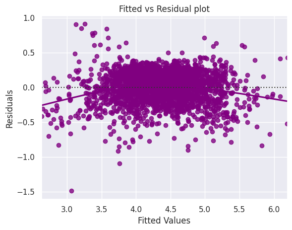

```python
# let's plot the fitted values vs residuals

sns.residplot(
    data=ReCell_1_pred, x="Fitted Values", y="Residuals", color="purple", lowess=True
)
plt.xlabel("Fitted Values")
plt.ylabel("Residuals")
plt.title("Fitted vs Residual plot")
plt.show()
```

### TEST FOR NORMALITY

**Why the test?**

- Error terms, or residuals, should be normally distributed. If the error terms are not normally distributed, confidence intervals of the coefficient estimates may become too wide or narrow. Once confidence interval becomes unstable, it leads to difficulty in estimating coefficients based on minimization of least squares. Non-normality suggests that there are a few unusual data points that must be studied closely to make a better model.

**How to check normality?**

- The shape of the histogram of residuals can give an initial idea about the normality.
- It can also be checked via a Q-Q plot of residuals. If the residuals follow a normal distribution, they will make a straight line plot, otherwise not.
- Other tests to check for normality includes the Shapiro-Wilk test.
  - Null hypothesis: Residuals are normally distributed
  - Alternate hypothesis: Residuals are not normally distributed

**How to fix if this assumption is not followed?**

- We can apply transformations like log, exponential, arcsinh, etc. as per our data.

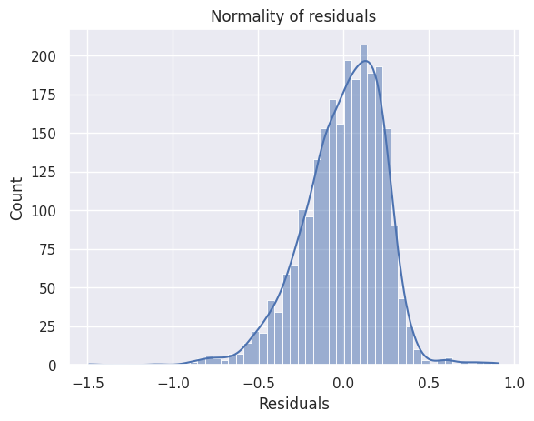

```python
sns.histplot(data=ReCell_1_pred, x="Residuals", kde=True)
plt.title("Normality of residuals")
plt.show()
```

- The histogram of residuals does have a bell shape, despite the left side and right side looking a little off with tails on each side.
- Let's check the Q-Q plot.

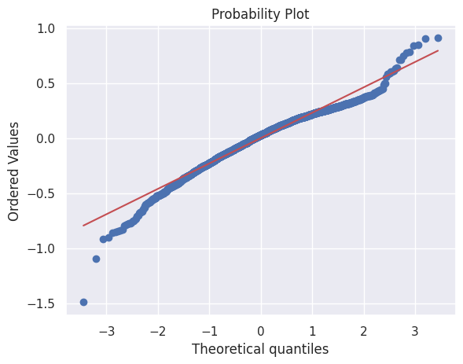

```python
import pylab
import scipy.stats as stats

stats.probplot(ReCell_1_pred["Residuals"], dist="norm", plot=pylab)
plt.show()
```

- The residuals more or less follow a straight line except for the tails and the part of the 2nd quantile.
- Let's check the results of the Shapiro-Wilk test.

```python
stats.shapiro(ReCell_1_pred["Residuals"])
```

```
ShapiroResult(statistic=0.970625638961792, pvalue=7.520647975304526e-22)
```

- Since p-value < 0.05, the residuals are not normal as per the Shapiro-Wilk test.
- Strictly speaking, the residuals are not normal.
- However, as an approximation, we can accept this distribution as close to being normal.
- **So, the assumption is satisfied.**

### TEST FOR HOMOSCEDASTICITY

- **Homoscedascity**: If the variance of the residuals is symmetrically distributed across the regression line, then the data is said to be homoscedastic.
- **Heteroscedascity**: If the variance is unequal for the residuals across the regression line, then the data is said to be heteroscedastic.

**Why the test?**

- The presence of non-constant variance in the error terms results in heteroscedasticity. Generally, non-constant variance arises in presence of outliers.

**How to check for homoscedasticity?**

- The residual vs fitted values plot can be looked at to check for homoscedasticity. In the case of heteroscedasticity, the residuals can form an arrow shape or any other non-symmetrical shape.
- The goldfeldquandt test can also be used. If we get a p-value > 0.05 we can say that the residuals are homoscedastic. Otherwise, they are heteroscedastic.
  - Null hypothesis: Residuals are homoscedastic
  - Alternate hypothesis: Residuals have heteroscedasticity

**How to fix if this assumption is not followed?**

- Heteroscedasticity can be fixed by adding other important features or making transformations.

```python
import statsmodels.stats.api as sms
from statsmodels.compat import lzip

name = ["F statistic", "p-value"]
test = sms.het_goldfeldquandt(ReCell_1_pred["Residuals"], x_train3)
lzip(name, test)
```

```
[('F statistic', 1.0064444937578416), ('p-value', 0.4558476973598104)]
```

**Since p-value > 0.05, we can say that the residuals are homoscedastic. So, this assumption is satisfied.**

## Predictions on test data

Now that we have checked all the assumptions of linear regression and they are satisfied, let's go ahead with prediction.

```python
# predictions on the test set
pred = olsmod2.predict(x_test3)

ReCell_1_pred_test = pd.DataFrame({"Actual": y_test, "Predicted": pred})
ReCell_1_pred_test.sample(10, random_state=1)
```

|  | Actual | Predicted |
| --- | --- | --- |
| 1995 | 4.566741 | 4.396852 |
| 2341 | 3.696103 | 3.983638 |
| 1913 | 3.592093 | 3.609233 |
| 688 | 4.306495 | 4.078466 |
| 650 | 4.522115 | 5.110239 |
| 2291 | 4.259294 | 4.370564 |
| 40 | 4.997685 | 5.468065 |
| 1884 | 3.875359 | 4.017058 |
| 2538 | 4.206631 | 4.039892 |
| 45 | 5.380450 | 5.301533 |

- We can observe here that our model has returned pretty good prediction results, and the actual and predicted values are comparable

## Final Model

```python
x_train_final = x_train3.copy()
x_test_final = x_test3.copy()
```

```python
olsmodel_final = sm.OLS(y_train, x_train_final).fit()
print(olsmodel_final.summary())
```

```
                              OLS Regression Results
=================================================================================
Dep. Variable:     normalized_used_price   R-squared:                       0.839
Model:                               OLS   Adj. R-squared:                  0.838
Method:                    Least Squares   F-statistic:                     837.2
Date:                   Sat, 15 Apr 2023   Prob (F-statistic):               0.00
Time:                           00:41:39   Log-Likelihood:                 82.585
No. Observations:                   2417   AIC:                            -133.2
Df Residuals:                       2401   BIC:                            -40.53
Df Model:                             15
Covariance Type:               nonrobust
========================================================================================
                           coef    std err          t      P>|t|      [0.025      0.975]
----------------------------------------------------------------------------------------
const                    1.5550      0.048     32.071      0.000       1.460       1.650
main_camera_mp           0.0205      0.001     14.829      0.000       0.018       0.023
selfie_camera_mp         0.0137      0.001     12.711      0.000       0.012       0.016
ram                      0.0195      0.004      4.363      0.000       0.011       0.028
weight                   0.0017      6e-05     27.664      0.000       0.002       0.002
normalized_new_price     0.4375      0.011     38.954      0.000       0.415       0.460
years                   -0.0303      0.003     -9.162      0.000      -0.037      -0.024
brand_name_LG           -0.0433      0.021     -2.020      0.043      -0.085      -0.001
brand_name_Micromax     -0.0550      0.028     -2.000      0.046      -0.109      -0.001
brand_name_Others       -0.0384      0.014     -2.664      0.008      -0.067      -0.010
brand_name_Samsung      -0.0514      0.017     -3.067      0.002      -0.084      -0.019
brand_name_Sony         -0.0684      0.031     -2.242      0.025      -0.128      -0.009
brand_name_Xiaomi        0.0771      0.026      2.993      0.003       0.027       0.128
os_Others               -0.1417      0.027     -5.264      0.000      -0.194      -0.089
os_iOS                  -0.0994      0.045     -2.198      0.028      -0.188      -0.011
4g_yes                   0.0458      0.015      3.018      0.003       0.016       0.076
==============================================================================
Omnibus:                      220.695   Durbin-Watson:                   1.897
Prob(Omnibus):                  0.000   Jarque-Bera (JB):              409.910
Skew:                          -0.618   Prob(JB):                     9.75e-90
Kurtosis:                       4.594   Cond. No.                     2.27e+03
==============================================================================

Notes:
[1] Standard Errors assume that the covariance matrix of the errors is correctly specified.
[2] The condition number is large, 2.27e+03. This might indicate that there are
strong multicollinearity or other numerical problems.
```

```python
# checking model performance on train set (seen 70% data)
print("Training Performance\n")
olsmodel_final_train_perf = model_performance_regression(
    olsmodel_final, x_train_final, y_train
)
olsmodel_final_train_perf
```

```
Training Performance
```

|  | RMSE | MAE | R-squared | Adj. R-squared | MAPE |
| --- | --- | --- | --- | --- | --- |
| 0 | 0.233843 | 0.182808 | 0.839498 | 0.838428 | 4.392176 |

```python
# checking model performance on test set (seen 30% data)
print("Test Performance\n")
olsmodel_final_test_perf = model_performance_regression(
    olsmodel_final, x_test_final, y_test
)
olsmodel_final_test_perf
```

```
Test Performance
```

|  | RMSE | MAE | R-squared | Adj. R-squared | MAPE |
| --- | --- | --- | --- | --- | --- |
| 0 | 0.241224 | 0.185969 | 0.838669 | 0.836138 | 4.541137 |

- The model is able to explain ~84% of the variation in the data
- The train and test RMSE and MAE are low and comparable. So, our model is not suffering from overfitting
- The MAPE on the test set suggests we can predict within 4.54% of the dynamic pricing strategy for used and refurbished devices
- Hence, we can conclude the model *olsmodel_final* is good for prediction as well as inference purposes

## Actionable Insights and Recommendations

The model is able to explain ~84% of the variation in the data and within 4.54% of the dynamic pricing strategy for used and refurbished devices on the test data, which is good

```
- This indicates that the model is good for prediction as well as inference purposes
```

If the main_camera_mp of a phone/tablet increases by one unit, then its nomalized_used_price increases by 0.0205 units, all other variables held constant

If the selfie_camera_mp of a phone/tablet increases by one unit, then its nomalized_used_price increases by 0.0137 units, all other variables held constant

If the ram of a phone/tablet increases by one unit, then its nomalized_used_price increases by 0.0195 units, all other variables held constant

If the weight of a phone/tablet increases by one unit, then its nomalized_used_price increases by 0.0017 units, all other variables held constant

If the new_used_price of a phone/tablet increases by one unit, then its nomalized_used_price increases by 0.4375 units, all other variables held constant

If the years of a phone/tablet increases by one unit, then its nomalized_used_price decreases by -0.0303 units, all other variables held constant

If the brand_name_LG of a phone/tablet increases by one unit, then its nomalized_used_price decreases by -0.0433 units, all other variables held constant

If the brand_name_Micromax of a phone/tablet increases by one unit, then its nomalized_used_price decreases by -0.0550 units, all other variables held constant

If the brand_name_Others of a phone/tablet increases by one unit, then its nomalized_used_price decreases by -0.0384 units, all other variables held constant

If the brand_name_Samsung of a phone/tablet increases by one unit, then its nomalized_used_price decreases by -0.0514 units, all other variables held constant

If the brand_name_Sony of a phone/tablet increases by one unit, then its nomalized_used_price decreases by -0.0684 units, all other variables held constant

If the brand_name_Xiaomi of a phone/tablet increases by one unit, then its nomalized_used_price increases by 0.0771 units, all other variables held constant

If the os-IOS of a phone/tablet increases by one unit, then its nomalized_used_price decreases by -0.0994 units, all other variables held constant

If the 4g_yes of a phone/tablet increases by one unit, then its nomalized_used_price increases by 0.0458 units, all other variables held constant

In developing a sound dynamic pricing strategy for used and refurbished devices, the company will need to ensure that devices have sufficent size main camera mp, selfie camera mp, and ram. Most people today use phones to take pictures opposed to traditonal cameras, and immediately upload to social media. Investing in devices with low featurs will result in a negative outcome and lost the company money, however, the more mp and ram the higher the payoff.